# IMDB_Capstone_CS_v2 slides

- Data Sources
- Gather the Data
- Explore the Data
  - Merge the titleBasics and titleRatings Data
  - Explore titleType From titleBasics
  - Explore Rows with Null Data
  - Determine What Timeframe to Include
  - Determine What Genres to Include
  - Save Dataframes for Other Notebooks
  - Determine the Target Average Rating
- Model the Data
  - Create Train & Test Datasets
    - Movie Genres Dataset
    - titlePrincipals Dataset
  - Movie Genre Dataset Modeling
    - Movie Genre Decision Tree Model
    - Movie Genre Random Forest Model
  - titlePrincipal Dataset Modeling
    - titlePrincipal Decision Tree
    - titlePrincipal Random Forest Model
    - titlePrincipal Random Forest Model with 2018 Validation Data
- Visualize the Results

## Data Sources

Description of the IMDB data: https://www.imdb.com/interfaces/

IMDB Data Sources: https://datasets.imdbws.com/

## Gather the Data

```python
%matplotlib inline
```

```python
import numpy as np
import pandas as pd
import seaborn as sns
import matplotlib.pyplot as plt
import statsmodels.api as sm
import scipy as sp
from scipy import stats
from scipy.stats import norm
```

```python
sns.set(rc={'figure.figsize': (12, 10), "lines.markeredgewidth": 0.5 })
```

```python
# display imdb documentation in the notebook
from IPython.display import IFrame
IFrame("../IMDB Dataset Descriptions.pdf", 800, 600)
```

[interactive chart not shown]

```python
# display imdb ER Diagram in the notebook
from IPython.display import IFrame
IFrame("../../Presentation/IMDB ERD.pdf", 800, 600)
```

[interactive chart not shown]

```python
#===============================================================================
#     READ INPUT DATA
#===============================================================================

#--------------------------------------------------------
#--  Input File 1:  name.basics.tsv
#--------------------------------------------------------
#print('Reading name.basics.tsv')
#nameBasics = pd.read_csv("../Data/name.basics.tsv/data.tsv", sep='\t')
#print('Complete - 1 of 7')
#print(nameBasics.head(5))

#--------------------------------------------------------
#--  Input File 2:  title.akas.tsv
#--------------------------------------------------------
#print('Reading title.akas.tsv')
#titleAkas = pd.read_csv("../Data/title.akas.tsv/data.tsv", sep='\t',dtype={"titleId": object, "ordering": object, "title": object, "region": object, "language": object, "types": object, "attributes": object, "isOriginalTitle": object})
#print('Complete - 2 of 7')
#print(titleAkas.head(5))

#--------------------------------------------------------
#--  Input File 3:  title.basics.tsv
#--------------------------------------------------------
print('Reading title.basics.tsv')
titleBasics = pd.read_csv("../Data/title.basics.tsv/data.tsv", sep='\t',dtype={"tconst": object, "titleType": object, "primaryTitle": object, "originalTitle": object, "isAdult": object, "startYear": object})
#print('Complete - 3 of 7')
titleBasics = titleBasics[titleBasics.isAdult == "0"]
print(titleBasics.head(5))

#--------------------------------------------------------
#--  Input File 4:  title.crew.tsv
#--------------------------------------------------------
#print('Reading title.crew.tsv')
#titleCrew = pd.read_csv("../Data/title.crew.tsv/data.tsv", sep='\t')
#print('Complete - 4 of 7')
#print(titleCrew.head(5))

#--------------------------------------------------------
#--  Input File 5:  title.episode.tsv
#--------------------------------------------------------
#print('Reading title.episode.tsv')
#titleEpisode = pd.read_csv("../Data/title.episode.tsv/data.tsv", sep='\t')
#print('Complete - 5 of 7')
#print(titleEpisode.head(5))

#--------------------------------------------------------
#--  Input File 6:  title.principals.tsv
#--------------------------------------------------------
#print('Reading title.principals.tsv')
#titlePrincipals = pd.read_csv("../Data/title.principals.tsv/data.tsv", sep='\t')
#print('Complete - 6 of 7')
#print(titlePrincipals.head(5))

#--------------------------------------------------------
#--  Input File 7:  title.ratings.tsv
#--------------------------------------------------------
print('Reading title.ratings.tsv')
titleRatings = pd.read_csv("../Data/title.ratings.tsv/data.tsv", sep='\t',dtype={"tconst": object, "averageRating": float, "numVotes": int})
print('CompletitleRatingste - 7 of 7')
print(titleRatings.head(5))

print('\n-----all data loaded -----')
```

```
Reading title.basics.tsv
      tconst titleType            primaryTitle           originalTitle  \
0  tt0000001     short              Carmencita              Carmencita
1  tt0000002     short  Le clown et ses chiens  Le clown et ses chiens
2  tt0000003     short          Pauvre Pierrot          Pauvre Pierrot
3  tt0000004     short             Un bon bock             Un bon bock
4  tt0000005     short        Blacksmith Scene        Blacksmith Scene

  isAdult startYear endYear runtimeMinutes                    genres
0       0      1894      \N              1         Documentary,Short
1       0      1892      \N              5           Animation,Short
2       0      1892      \N              4  Animation,Comedy,Romance
3       0      1892      \N             \N           Animation,Short
4       0      1893      \N              1                     Short
Reading title.ratings.tsv
CompletitleRatingste - 7 of 7
      tconst  averageRating  numVotes
0  tt0000001            5.8      1391
1  tt0000002            6.5       163
2  tt0000003            6.6       979
3  tt0000004            6.4        98
4  tt0000005            6.2      1673

-----all data loaded -----
```

## Explore the Data

```python
titleBasics.describe()
```

|  | tconst | titleType | primaryTitle | originalTitle | isAdult | startYear | endYear | runtimeMinutes | genres |
| --- | --- | --- | --- | --- | --- | --- | --- | --- | --- |
| count | 4995016 | 4995016 | 4995010 | 4995010 | 4995016 | 4995016 | 4995016 | 4995016 | 4995016 |
| unique | 4995016 | 10 | 2592549 | 2606278 | 1 | 146 | 94 | 776 | 2080 |
| top | tt1443054 | tvEpisode | Episode #1.1 | Episode #1.1 | 0 | \N | \N | \N | \N |
| freq | 1 | 3413257 | 28808 | 28814 | 4995016 | 292947 | 4954210 | 3465520 | 406668 |

```python
titleRatings.describe()
```

|  | averageRating | numVotes |
| --- | --- | --- |
| count | 852306.000000 | 8.523060e+05 |
| mean | 6.929305 | 9.783524e+02 |
| std | 1.395433 | 1.537121e+04 |
| min | 1.000000 | 5.000000e+00 |
| 25% | 6.200000 | 9.000000e+00 |
| 50% | 7.100000 | 2.000000e+01 |
| 75% | 7.900000 | 7.700000e+01 |
| max | 10.000000 | 1.974184e+06 |

```python
len(titleBasics) - len(titleRatings)
```

```
4142710
```

Will need to look at removing NaN were appropriate and get a subset of data that contains only movies.

### Merge the titleBasics and titleRatings Data

No need to rename columns as the column names are already consistent and have a way to join naturally using the `tconst` column.

Use of the pandas database-style [`merge()`](http://pandas.pydata.org/pandas-docs/stable/merging.html#database-style-dataframe-joining-merging) function.

```python
# returns an inner join of both dataframes
title_data = pd.merge(titleBasics, titleRatings, how='inner', on=['tconst'])

# Check the length of the resulting join
len(title_data)
```

```
835236
```

```python
title_data.head()
```

|  | tconst | titleType | primaryTitle | originalTitle | isAdult | startYear | endYear | runtimeMinutes | genres | averageRating | numVotes |
| --- | --- | --- | --- | --- | --- | --- | --- | --- | --- | --- | --- |
| 0 | tt0000001 | short | Carmencita | Carmencita | 0 | 1894 | \N | 1 | Documentary,Short | 5.8 | 1391 |
| 1 | tt0000002 | short | Le clown et ses chiens | Le clown et ses chiens | 0 | 1892 | \N | 5 | Animation,Short | 6.5 | 163 |
| 2 | tt0000003 | short | Pauvre Pierrot | Pauvre Pierrot | 0 | 1892 | \N | 4 | Animation,Comedy,Romance | 6.6 | 979 |
| 3 | tt0000004 | short | Un bon bock | Un bon bock | 0 | 1892 | \N | \N | Animation,Short | 6.4 | 98 |
| 4 | tt0000005 | short | Blacksmith Scene | Blacksmith Scene | 0 | 1893 | \N | 1 | Short | 6.2 | 1673 |

### Explore titleType From titleBasics

```python
title_data.titleType.value_counts()
```

```
tvEpisode       356931
movie           217354
short           102739
tvSeries         58110
tvMovie          42220
video            32514
videoGame         8551
tvMiniSeries      8045
tvSpecial         6353
tvShort           2419
Name: titleType, dtype: int64
```

TitleTypes to include:

- movie

TitleTypes to consider (similar to movies, these have one runtime with no endYear value):

- short, tvMovie, video, tvSpecial, tvShort

Apply a mask that removes all title types that are not `movies`, then save the results to a new dataframe. Next remove unused columns that contain all NaN or null values.

```python
# remove all titleTypes except for movies
movie_data = title_data[title_data.titleType == 'movie']

# drop unused columns
movie_data = movie_data.drop(['titleType', 'isAdult', 'endYear'], axis=1)

movie_data.head()
```

|  | tconst | primaryTitle | originalTitle | startYear | runtimeMinutes | genres | averageRating | numVotes |
| --- | --- | --- | --- | --- | --- | --- | --- | --- |
| 8 | tt0000009 | Miss Jerry | Miss Jerry | 1894 | 45 | Romance | 5.5 | 67 |
| 142 | tt0000147 | The Corbett-Fitzsimmons Fight | The Corbett-Fitzsimmons Fight | 1897 | 20 | Documentary,News,Sport | 5.2 | 259 |
| 235 | tt0000335 | Soldiers of the Cross | Soldiers of the Cross | 1900 | \N | Biography,Drama | 6.2 | 35 |
| 337 | tt0000574 | The Story of the Kelly Gang | The Story of the Kelly Gang | 1906 | 70 | Biography,Crime,Drama | 6.3 | 463 |
| 353 | tt0000615 | Robbery Under Arms | Robbery Under Arms | 1907 | \N | Drama | 5.1 | 13 |

### Explore Rows with Null Data

Next will explore rows with null data and will need to decide if they should be included in the final dataset. As well as explore the datatypes of rows with numerical data.

To convert the `startYear` type from an Object to an Int datatype, we need to fill all NaN rows with zero. This allows for the columns to be used in calculations and charts.

**Decision:** Since there are less than 5 rows that do not have a start year, we will remove all '0' values from this column.

```python
# replace values with '\N' with the pandas 'NaN'
# source: https://stackoverflow.com/a/49406417
movie_data = movie_data.replace({'\\N': np.nan})

# fill NaN rows with 0
movie_data['startYear'] = movie_data.startYear.fillna(0)

# convert the column to datatype of int
movie_data['startYear'] = movie_data.startYear.astype(int)

# drop the rows that contain a startYear of 0
# source: https://chrisalbon.com/python/data_wrangling/pandas_dropping_column_and_rows/
movie_data = movie_data[movie_data.startYear != 0]
```

```python
# check what rows are missing data
movie_data.isnull().sum()
```

```
tconst                0
primaryTitle          0
originalTitle         1
startYear             0
runtimeMinutes    27288
genres            13553
averageRating         0
numVotes              0
dtype: int64
```

The `runtimMinutes` is currently the only column that is an object but may consider turning to a type of int.

**Decision Needed:** Should the NaN/0 values remain in the final cleaned dataset?

```python
# fill NaN rows with 0
movie_data['runtimeMinutes'] = movie_data.runtimeMinutes.fillna(0)

# convert the column to datatype of int
movie_data['runtimeMinutes'] = movie_data.runtimeMinutes.astype(int)
```

```python
# check what rows are missing data
movie_data.isnull().sum()
```

```
tconst                0
primaryTitle          0
originalTitle         1
startYear             0
runtimeMinutes        0
genres            13553
averageRating         0
numVotes              0
dtype: int64
```

### Determine What Timeframe to Include

Why limit the timeframe? Movies release before a certain period of time are not being reviewed as they are release, where many of the reviews may come from viewers watching the movie(s) years after the initial release. For example, the data from IMDB would not have reviews from the year 1894, the same year the movie was released.

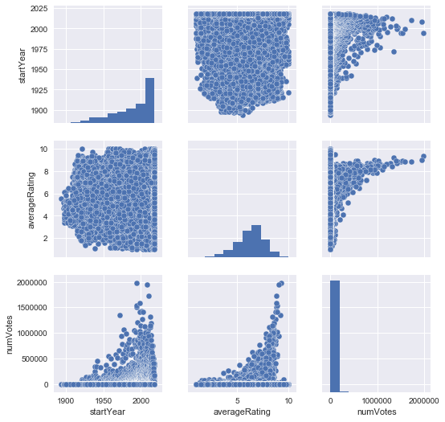

```python
sns.pairplot(data=movie_data[['startYear', 'averageRating', 'numVotes']])
```

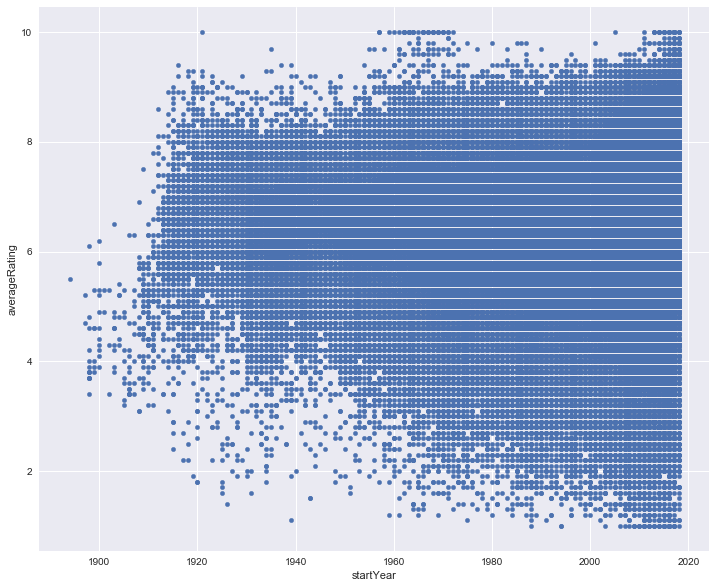

```python
movie_data.plot.scatter(x="startYear", y="averageRating")
```

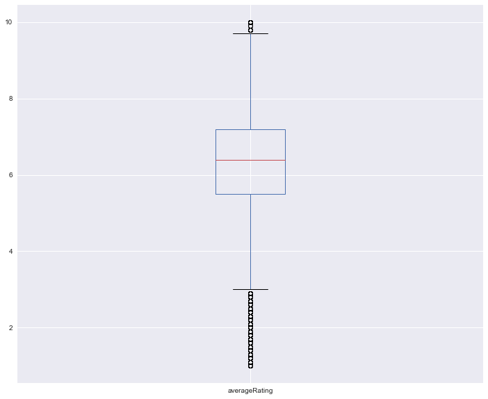

```python
movie_data.averageRating.plot(kind='box')
```

Calculate the thresholds for the outliers.

```python
q1 = movie_data.averageRating.quantile(0.25)  # first quartile
q3 = movie_data.averageRating.quantile(0.75)  # third quartile
IQR = q3 - q1  # IQR
lower_threshold = q1 - 1.5 * IQR  # lower threshold
upper_threshold = q3 + 1.5 * IQR  # upper threshold
display(lower_threshold, upper_threshold)
```

```
2.9499999999999997
```

```
9.75
```

Pivot table that looks at the average movie rating for each year.

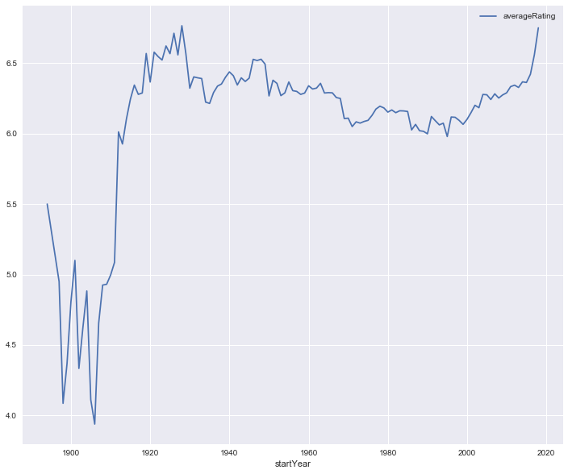

```python
movie_pivot = movie_data.pivot_table(index="startYear", values=["averageRating"])

movie_pivot.plot(kind='line')
```

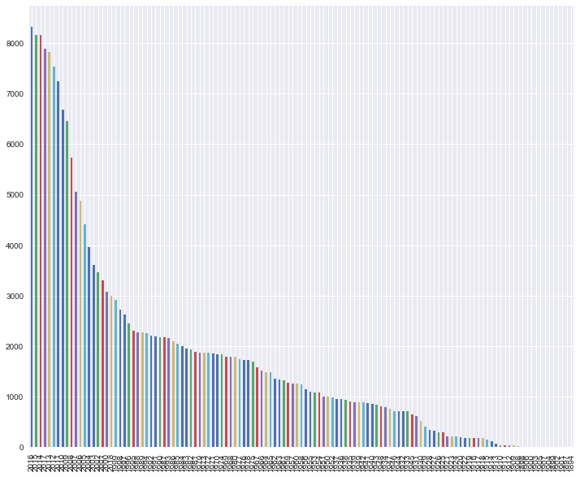

```python
# plot the number of movie reviews per year
movie_pivot = movie_data['startYear'].value_counts()

movie_pivot.plot(kind='bar')
```

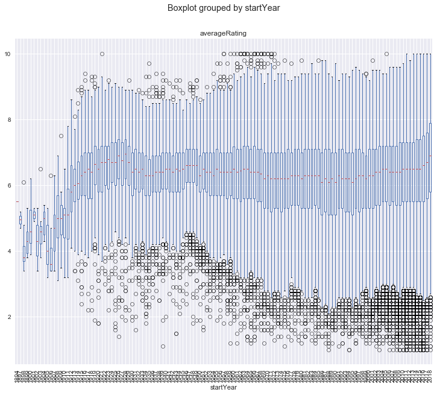

```python
movie_data.boxplot(column='averageRating', by='startYear')
plt.xticks(rotation=90)
```

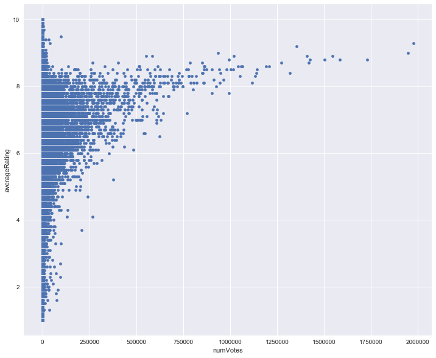

```python
movie_data.plot.scatter(x="numVotes", y="averageRating")
```

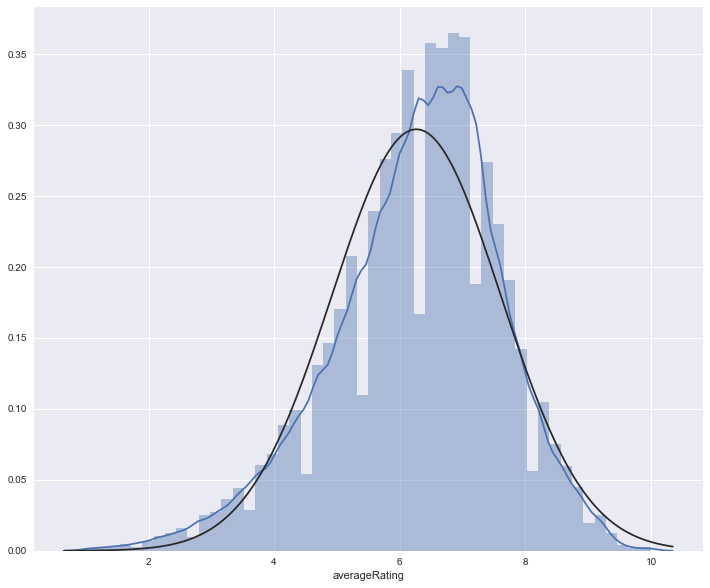

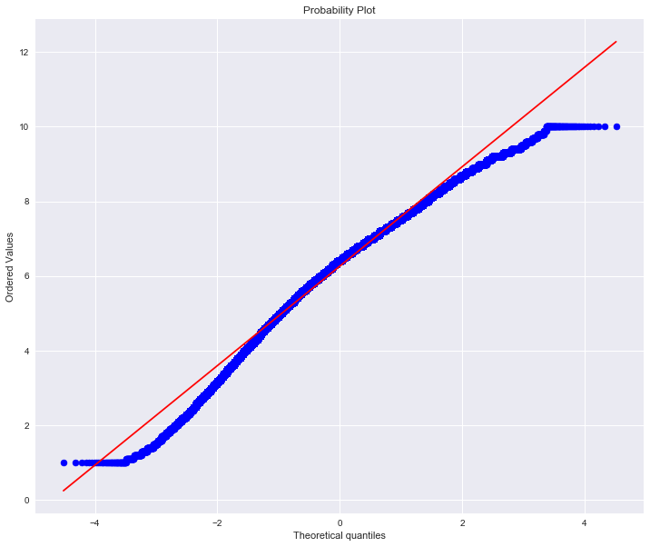

```python
# test the normality of averageRating (should look like a normal distribution)
# histogram & normal probability plot
sns.distplot(movie_data['averageRating'], fit=norm)
fig = plt.figure()
res = stats.probplot(movie_data['averageRating'], plot=plt)
```

```python
ratings = movie_data['averageRating']
ratings_mean = ratings.mean()
ratings_median = ratings.median()

# compute descriptive summary stats of the movie ratings
ratings_summary = ratings.describe()

ratings_mode = sp.stats.mode(ratings)
skew = ratings.skew()
kurt = ratings.kurt()

# compute quantiles
ninety = ratings.quantile(0.9)
eighty = ratings.quantile(0.8)
seventy = ratings.quantile(0.7)
sixty = ratings.quantile(0.6)

print('Skew: ', str(skew))
print('Kurtosis: ', str(kurt))
print('90%: ', str(ninety))
print('80%: ', str(eighty))
print('70%: ', str(seventy))
print('60%: ', str(sixty))
print(ratings_summary)
```

```
Skew:  -0.512744130668522
Kurtosis:  0.3977808846222439
90%:  7.8
80%:  7.3
70%:  7.0
60%:  6.7
count    217352.000000
mean          6.263369
std           1.343145
min           1.000000
25%           5.500000
50%           6.400000
75%           7.200000
max          10.000000
Name: averageRating, dtype: float64
```

```
count    217352.000000
mean          6.263369
std           1.343145
min           1.000000
25%           5.500000
50%           6.400000
75%           7.200000
max          10.000000
Name: averageRating, dtype: float64
```

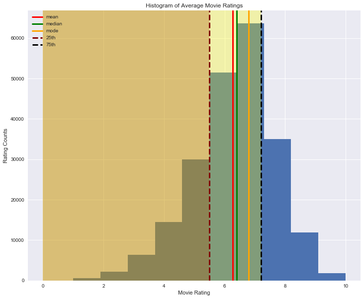

```python
# histogram
h = movie_data['averageRating'].hist(bins=10)

# summary statistics vertical lines
h.axvline(x=ratings_mean, color='red', ls='solid', lw='3', label='mean')
h.axvline(x=ratings_median, color='green', ls='solid', lw='3', label='median')
h.axvline(x=ratings_mode[0][0], color='orange', ls='solid', lw='3', label='mode')

# 25th quantile
h.axvline(x=ratings_summary['25%'], color='maroon', ls='dashed', lw='3', label='25th')
h.axvspan(0, ratings_summary['25%'], facecolor='maroon', alpha=0.3)

# 75th quantile
h.axvline(x=ratings_summary['75%'], color='black', ls='dashed', lw='3', label='75th')
h.axvspan(0, ratings_summary['75%'], facecolor='yellow', alpha=0.3)

# add legend to graph
h.legend(loc=2)

# add a title to the figure
h.set_title('Histogram of Average Movie Ratings')

# set axis labels
h.set_xlabel('Movie Rating')
h.set_ylabel('Rating Counts')

print(ratings_summary)
```

It appears the general trend is that average movie ratings increases each year sometime after the year 2000. Should explore reasons why. Could be movie saturation?

This dataset also shows at first glance that the more votes a movie receives, the better the average rating. Similar concept to if the movie is bad, you may see primarily negative reviews.

IMDB was established in 1990.

**Decision:** Analyze movies that occur on or after the year 1920.

```python
current_movie_data = movie_data[movie_data.startYear >= 1920]
```

```python
current_movie_data.head()
```

|  | tconst | primaryTitle | originalTitle | startYear | runtimeMinutes | genres | averageRating | numVotes |
| --- | --- | --- | --- | --- | --- | --- | --- | --- |
| 1166 | tt0003854 | Dodge City Trail | Dodge City Trail | 1936 | 56 | Adventure,Music,Western | 5.6 | 9 |
| 1358 | tt0005076 | Charley's Aunt | Charley's Aunt | 1925 | 80 | Comedy | 6.7 | 37 |
| 1959 | tt0008933 | Die Brüder Karamasoff | Die Brüder Karamasoff | 1921 | 70 | Drama | 9.0 | 8 |
| 2115 | tt0009771 | A víg özvegy | A víg özvegy | 1920 | 70 | Musical | 5.2 | 12 |
| 2166 | tt0010058 | The Deadlier Sex | The Deadlier Sex | 1920 | 60 | Comedy,Drama | 6.9 | 8 |

```python
len(current_movie_data)
```

```
216015
```

```python
q1 = current_movie_data.averageRating.quantile(0.25)  # first quartile
q3 = current_movie_data.averageRating.quantile(0.75)  # third quartile
IQR = q3 - q1  # IQR
lower_threshold = q1 - 1.5 * IQR  # lower threshold
upper_threshold = q3 + 1.5 * IQR  # upper threshold
display(lower_threshold, upper_threshold)
```

```
2.9499999999999997
```

```
9.75
```

Can infer movie saturation may be the cause for the trend of positive movie ratings.

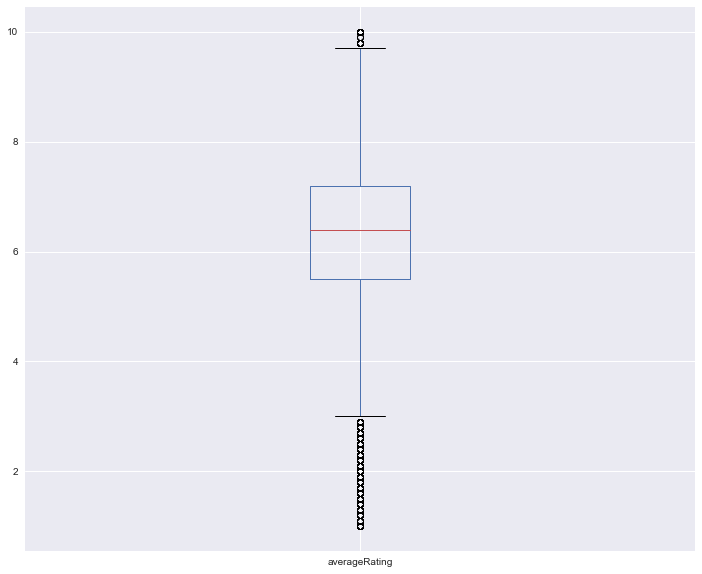

```python
current_movie_data.averageRating.plot(kind='box')
```

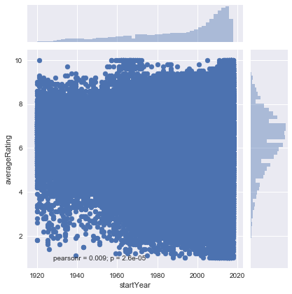

```python
sns.jointplot(x='startYear', y='averageRating',
              data=current_movie_data, kind='scatter');
```

### Determine What Genres to Include

Currently all genres for a movie title are comma separated into one column. Next will one-hot encode, [What is One Hot Encoding? Why And When do you have to use it?](https://hackernoon.com/what-is-one-hot-encoding-why-and-when-do-you-have-to-use-it-e3c6186d008f), the genre features by separating each genre into it's own column with a boolean value.

```python
# Used for Proof of Concept
#current_movie_data.to_csv("../Data/current_movie_data.csv", sep='\t', index=False)
```

```python
movies_genres_list = current_movie_data['genres'].tolist()

# convert all values to a string and return the map as a list
# source: https://stackoverflow.com/a/1303354
movies_genres_list = list(map(str, movies_genres_list))

#movies_genres_list
```

```python
def get_genres(comma_list):
    '''Returns a sorted list of genres from the dataset'''
    genre_dict = dict()  # { key='genre': val='count' }
    genre_list = list()

    for index, val in enumerate(comma_list):
        # create a list of lists for each movie entry
        split_list = comma_list[index].split(',')

        # store each genre as one entry in the dictionary
        for index, val in enumerate(split_list):
            genre_dict[val] = genre_dict.get(val, 0) + 1

    return convert_dict_to_string(genre_dict)


def convert_dict_to_string(dictionary):
    '''Sorts a dictionary into a list of sorted keys'''
    sortedList = list()

    # Create a list of keys
    for key, val in dictionary.items():
        sortedList.append(key)

    sortedList.sort()

    return sortedList


genres_list = get_genres(movies_genres_list)
```

```python
# create a new subset of data for when we explode the genre columns
movie_data_expanded = current_movie_data.copy()

# convert the NaN values to a string so they are not a float value & throw an error
movie_data_expanded['genres'] = movie_data_expanded.genres.fillna('')
```

```python
def find_Value(value, subString):
    '''Returns 1 if True, 0 otherwise'''
    if subString in value:
        return 1
    else:
        return 0

def split_genre_columns(list_of_genres):
    '''Explodes the genres column where there is one new column for each genre in the dataset.
       Each new column has a True/False value that corresponds to the genres column.'''
    print('Number of genres:', len(list_of_genres))
    for index, val in enumerate(list_of_genres):
        print(list_of_genres[index])
        movie_data_expanded[list_of_genres[index]] = movie_data_expanded.apply(lambda x: find_Value(x['genres'], list_of_genres[index]), axis=1)

        # convert the column to datatype of integer
        movie_data_expanded[list_of_genres[index]] = movie_data_expanded[list_of_genres[index]].astype(int)
        #movie_data_expanded[list_of_genres[index]].str.strip()  # needed if converting to True/False values

split_genre_columns(genres_list)  #explode the genre columns
movie_data_expanded.head()
```

```
Number of genres: 29
Action
Adult
Adventure
Animation
Biography
Comedy
Crime
Documentary
Drama
Family
Fantasy
Film-Noir
Game-Show
History
Horror
Music
Musical
Mystery
News
Reality-TV
Romance
Sci-Fi
Short
Sport
Talk-Show
Thriller
War
Western
nan
```

|  | tconst | primaryTitle | originalTitle | startYear | runtimeMinutes | genres | averageRating | numVotes | Action | Adult | ... | Reality-TV | Romance | Sci-Fi | Short | Sport | Talk-Show | Thriller | War | Western | nan |
| --- | --- | --- | --- | --- | --- | --- | --- | --- | --- | --- | --- | --- | --- | --- | --- | --- | --- | --- | --- | --- | --- |
| 1166 | tt0003854 | Dodge City Trail | Dodge City Trail | 1936 | 56 | Adventure,Music,Western | 5.6 | 9 | 0 | 0 | ... | 0 | 0 | 0 | 0 | 0 | 0 | 0 | 0 | 1 | 0 |
| 1358 | tt0005076 | Charley's Aunt | Charley's Aunt | 1925 | 80 | Comedy | 6.7 | 37 | 0 | 0 | ... | 0 | 0 | 0 | 0 | 0 | 0 | 0 | 0 | 0 | 0 |
| 1959 | tt0008933 | Die Brüder Karamasoff | Die Brüder Karamasoff | 1921 | 70 | Drama | 9.0 | 8 | 0 | 0 | ... | 0 | 0 | 0 | 0 | 0 | 0 | 0 | 0 | 0 | 0 |
| 2115 | tt0009771 | A víg özvegy | A víg özvegy | 1920 | 70 | Musical | 5.2 | 12 | 0 | 0 | ... | 0 | 0 | 0 | 0 | 0 | 0 | 0 | 0 | 0 | 0 |
| 2166 | tt0010058 | The Deadlier Sex | The Deadlier Sex | 1920 | 60 | Comedy,Drama | 6.9 | 8 | 0 | 0 | ... | 0 | 0 | 0 | 0 | 0 | 0 | 0 | 0 | 0 | 0 |

5 rows × 37 columns

Need to explore why there are certain genres in the dataset such as Adult (filter this out previously), Game-Show, Reality-TV, Short, and Talk-Show.

```python
movie_data_expanded.nan.unique()
```

```
array([0], dtype=int64)
```

**Decision Needed:** Could keep or remove the `nan` column from the resulting genre list. If kept, it would need to be updated to be `True` for everywhere there is a `''` value in the `genres` column.

```python
# source: https://stackoverflow.com/a/19226617
movie_data_expanded.loc[movie_data_expanded.genres == '', 'nan'] = 1
```

```python
# double check the same number of null values exist as before
movie_data_expanded[movie_data_expanded.genres == ''].genres.value_counts()
```

```
    13251
Name: genres, dtype: int64
```

```python
movie_data_expanded.nan.value_counts()
```

```
0    202764
1     13251
Name: nan, dtype: int64
```

```python
movie_data_expanded[movie_data_expanded.nan == 1].head()
```

|  | tconst | primaryTitle | originalTitle | startYear | runtimeMinutes | genres | averageRating | numVotes | Action | Adult | ... | Reality-TV | Romance | Sci-Fi | Short | Sport | Talk-Show | Thriller | War | Western | nan |
| --- | --- | --- | --- | --- | --- | --- | --- | --- | --- | --- | --- | --- | --- | --- | --- | --- | --- | --- | --- | --- | --- |
| 2191 | tt0010186 | Die Gottesgeisel | Die Gottesgeisel | 1920 | 0 |  | 4.7 | 14 | 0 | 0 | ... | 0 | 0 | 0 | 0 | 0 | 0 | 0 | 0 | 0 | 1 |
| 2345 | tt0011011 | Boccaccio | Boccaccio | 1920 | 0 |  | 5.9 | 12 | 0 | 0 | ... | 0 | 0 | 0 | 0 | 0 | 0 | 0 | 0 | 0 | 1 |
| 2348 | tt0011024 | The Breaking of the Drought | The Breaking of the Drought | 1920 | 87 |  | 5.5 | 10 | 0 | 0 | ... | 0 | 0 | 0 | 0 | 0 | 0 | 0 | 0 | 0 | 1 |
| 2375 | tt0011137 | Good and Evil | Herzogin Satanella | 1921 | 0 |  | 5.5 | 11 | 0 | 0 | ... | 0 | 0 | 0 | 0 | 0 | 0 | 0 | 0 | 0 | 1 |
| 2385 | tt0011216 | Spanish Fiesta | La fête espagnole | 1920 | 0 |  | 7.7 | 14 | 0 | 0 | ... | 0 | 0 | 0 | 0 | 0 | 0 | 0 | 0 | 0 | 1 |

5 rows × 37 columns

```python
movie_data_expanded[movie_data_expanded['Talk-Show'] == 1]
```

|  | tconst | primaryTitle | originalTitle | startYear | runtimeMinutes | genres | averageRating | numVotes | Action | Adult | ... | Reality-TV | Romance | Sci-Fi | Short | Sport | Talk-Show | Thriller | War | Western | nan |
| --- | --- | --- | --- | --- | --- | --- | --- | --- | --- | --- | --- | --- | --- | --- | --- | --- | --- | --- | --- | --- | --- |
| 23684 | tt0045338 | The Woman's Angle | The Woman's Angle | 1952 | 86 | Drama,Romance,Talk-Show | 5.5 | 11 | 0 | 0 | ... | 0 | 1 | 0 | 0 | 0 | 1 | 0 | 0 | 0 | 0 |
| 137929 | tt0250811 | Vincent Price: The Sinister Image | Vincent Price: The Sinister Image | 1987 | 192 | Biography,Documentary,Talk-Show | 8.3 | 65 | 0 | 0 | ... | 0 | 0 | 0 | 0 | 0 | 1 | 0 | 0 | 0 | 0 |
| 682405 | tt4008976 | 9.3 Masaru Sato's Talk Show: The Intelligent R... | 9.3 Masaru Sato's Talk Show: The Intelligent R... | 2014 | 90 | Talk-Show | 8.5 | 537 | 0 | 0 | ... | 0 | 0 | 0 | 0 | 0 | 1 | 0 | 0 | 0 | 0 |
| 790023 | tt6522846 | Grillo vs Grillo | Grillo vs Grillo | 2017 | 0 | Comedy,Talk-Show | 5.7 | 78 | 0 | 0 | ... | 0 | 0 | 0 | 0 | 0 | 1 | 0 | 0 | 0 | 0 |
| 825884 | tt7909176 | Flower Boy: A Conversation | Flower Boy: A Conversation | 2018 | 58 | Comedy,Documentary,Talk-Show | 9.6 | 7 | 0 | 0 | ... | 0 | 0 | 0 | 0 | 0 | 1 | 0 | 0 | 0 | 0 |

5 rows × 37 columns

#### Determine Stats For Each Genre

```python
# create a new dataframe to rollup genre stats
genre_avg = pd.DataFrame(columns = ['genre', 'averageRating', 'max', 'min', 'count', 'stdDev',
                                    'numVotes', 'avgRuntimeMinutes'])
```

```python
def calc_genre_avgs(list_genres):
    '''Populate an empty dataframe with calculated values for all genres in the dataset'''
    for index, val in enumerate(list_genres):
        # mask all data for the current genre
        genreData_temp = movie_data_expanded[movie_data_expanded[list_genres[index]] == 1]

        genre_avg.loc[index] = [list_genres[index], genreData_temp.averageRating.mean(),
                                genreData_temp.averageRating.max(), genreData_temp.averageRating.min(),
                                genreData_temp.averageRating.count(), genreData_temp.averageRating.std(ddof=1),
                                genreData_temp.numVotes.mean(), genreData_temp.runtimeMinutes.mean()]

calc_genre_avgs(genres_list)
genre_avg
```

|  | genre | averageRating | max | min | count | stdDev | numVotes | avgRuntimeMinutes |
| --- | --- | --- | --- | --- | --- | --- | --- | --- |
| 0 | Action | 5.797580 | 9.8 | 1.0 | 22440 | 1.341515 | 9068.355526 | 87.820722 |
| 1 | Adult | 5.321429 | 6.7 | 3.3 | 14 | 1.149032 | 101.642857 | 73.357143 |
| 2 | Adventure | 6.067538 | 10.0 | 1.0 | 13009 | 1.300192 | 14191.610116 | 87.892228 |
| 3 | Animation | 6.424893 | 9.4 | 1.1 | 3507 | 1.177903 | 11118.893356 | 75.583975 |
| 4 | Biography | 7.069247 | 10.0 | 1.1 | 6266 | 1.056699 | 6608.992340 | 92.115863 |
| 5 | Comedy | 6.026544 | 9.8 | 1.0 | 55162 | 1.277517 | 3723.258674 | 85.082647 |
| 6 | Crime | 6.118861 | 10.0 | 1.1 | 18302 | 1.172880 | 7336.791826 | 89.473391 |
| 7 | Documentary | 7.306157 | 10.0 | 1.0 | 29204 | 1.097835 | 279.647959 | 75.833516 |
| 8 | Drama | 6.382903 | 10.0 | 1.0 | 94332 | 1.172117 | 3620.583736 | 89.659585 |
| 9 | Family | 6.330322 | 10.0 | 1.0 | 8324 | 1.289085 | 4271.971288 | 84.363287 |
| 10 | Fantasy | 6.015357 | 9.6 | 1.1 | 6095 | 1.330679 | 12218.312387 | 87.026907 |
| 11 | Film-Noir | 6.657520 | 8.5 | 3.0 | 758 | 0.666892 | 3233.527704 | 83.382586 |
| 12 | Game-Show | 5.700000 | 7.6 | 3.3 | 5 | 1.601562 | 118.000000 | 173.000000 |
| 13 | History | 6.928426 | 10.0 | 1.1 | 5597 | 1.093941 | 4052.385921 | 95.847240 |
| 14 | Horror | 5.141307 | 9.7 | 1.0 | 14639 | 1.397716 | 4214.220234 | 81.464649 |
| 15 | Music | 6.569152 | 10.0 | 1.0 | 10218 | 1.274402 | 1917.829908 | 88.219808 |
| 16 | Musical | 6.311082 | 9.6 | 1.2 | 5315 | 1.231345 | 1287.731326 | 90.107432 |
| 17 | Mystery | 6.054910 | 9.9 | 1.0 | 7698 | 1.221299 | 8572.393089 | 88.810340 |
| 18 | News | 7.314943 | 9.4 | 2.0 | 609 | 1.040317 | 251.660099 | 77.812808 |
| 19 | Reality-TV | 6.386957 | 9.1 | 2.7 | 23 | 1.938440 | 49.826087 | 60.695652 |
| 20 | Romance | 6.230206 | 9.8 | 1.0 | 24012 | 1.141157 | 3860.322297 | 89.361944 |
| 21 | Sci-Fi | 5.379016 | 9.8 | 1.0 | 5385 | 1.441250 | 16810.944661 | 85.748375 |
| 22 | Short | 5.200000 | 5.2 | 5.2 | 1 | NaN | 28.000000 | 10.000000 |
| 23 | Sport | 6.672055 | 9.9 | 1.2 | 2394 | 1.327053 | 5099.676692 | 87.261905 |
| 24 | Talk-Show | 7.520000 | 9.6 | 5.5 | 5 | 1.822635 | 139.600000 | 85.200000 |
| 25 | Thriller | 5.715994 | 9.6 | 1.0 | 17325 | 1.341063 | 6989.833420 | 88.646118 |
| 26 | War | 6.559185 | 10.0 | 1.1 | 4856 | 1.158052 | 3234.432249 | 94.935544 |
| 27 | Western | 6.031159 | 9.3 | 1.2 | 4063 | 1.041069 | 1771.380753 | 77.917795 |
| 28 | nan | 6.258222 | 10.0 | 1.0 | 13251 | 1.446979 | 21.155837 | 52.619878 |

```python
genre_avg.sort_values(by='stdDev', ascending=True)
```

|  | genre | averageRating | max | min | count | stdDev | numVotes | avgRuntimeMinutes |
| --- | --- | --- | --- | --- | --- | --- | --- | --- |
| 11 | Film-Noir | 6.657520 | 8.5 | 3.0 | 758 | 0.666892 | 3233.527704 | 83.382586 |
| 18 | News | 7.314943 | 9.4 | 2.0 | 609 | 1.040317 | 251.660099 | 77.812808 |
| 27 | Western | 6.031159 | 9.3 | 1.2 | 4063 | 1.041069 | 1771.380753 | 77.917795 |
| 4 | Biography | 7.069247 | 10.0 | 1.1 | 6266 | 1.056699 | 6608.992340 | 92.115863 |
| 13 | History | 6.928426 | 10.0 | 1.1 | 5597 | 1.093941 | 4052.385921 | 95.847240 |
| 7 | Documentary | 7.306157 | 10.0 | 1.0 | 29204 | 1.097835 | 279.647959 | 75.833516 |
| 20 | Romance | 6.230206 | 9.8 | 1.0 | 24012 | 1.141157 | 3860.322297 | 89.361944 |
| 1 | Adult | 5.321429 | 6.7 | 3.3 | 14 | 1.149032 | 101.642857 | 73.357143 |
| 26 | War | 6.559185 | 10.0 | 1.1 | 4856 | 1.158052 | 3234.432249 | 94.935544 |
| 8 | Drama | 6.382903 | 10.0 | 1.0 | 94332 | 1.172117 | 3620.583736 | 89.659585 |
| 6 | Crime | 6.118861 | 10.0 | 1.1 | 18302 | 1.172880 | 7336.791826 | 89.473391 |
| 3 | Animation | 6.424893 | 9.4 | 1.1 | 3507 | 1.177903 | 11118.893356 | 75.583975 |
| 17 | Mystery | 6.054910 | 9.9 | 1.0 | 7698 | 1.221299 | 8572.393089 | 88.810340 |
| 16 | Musical | 6.311082 | 9.6 | 1.2 | 5315 | 1.231345 | 1287.731326 | 90.107432 |
| 15 | Music | 6.569152 | 10.0 | 1.0 | 10218 | 1.274402 | 1917.829908 | 88.219808 |
| 5 | Comedy | 6.026544 | 9.8 | 1.0 | 55162 | 1.277517 | 3723.258674 | 85.082647 |
| 9 | Family | 6.330322 | 10.0 | 1.0 | 8324 | 1.289085 | 4271.971288 | 84.363287 |
| 2 | Adventure | 6.067538 | 10.0 | 1.0 | 13009 | 1.300192 | 14191.610116 | 87.892228 |
| 23 | Sport | 6.672055 | 9.9 | 1.2 | 2394 | 1.327053 | 5099.676692 | 87.261905 |
| 10 | Fantasy | 6.015357 | 9.6 | 1.1 | 6095 | 1.330679 | 12218.312387 | 87.026907 |
| 25 | Thriller | 5.715994 | 9.6 | 1.0 | 17325 | 1.341063 | 6989.833420 | 88.646118 |
| 0 | Action | 5.797580 | 9.8 | 1.0 | 22440 | 1.341515 | 9068.355526 | 87.820722 |
| 14 | Horror | 5.141307 | 9.7 | 1.0 | 14639 | 1.397716 | 4214.220234 | 81.464649 |
| 21 | Sci-Fi | 5.379016 | 9.8 | 1.0 | 5385 | 1.441250 | 16810.944661 | 85.748375 |
| 28 | nan | 6.258222 | 10.0 | 1.0 | 13251 | 1.446979 | 21.155837 | 52.619878 |
| 12 | Game-Show | 5.700000 | 7.6 | 3.3 | 5 | 1.601562 | 118.000000 | 173.000000 |
| 24 | Talk-Show | 7.520000 | 9.6 | 5.5 | 5 | 1.822635 | 139.600000 | 85.200000 |
| 19 | Reality-TV | 6.386957 | 9.1 | 2.7 | 23 | 1.938440 | 49.826087 | 60.695652 |
| 22 | Short | 5.200000 | 5.2 | 5.2 | 1 | NaN | 28.000000 | 10.000000 |

```python
genre_corr = movie_data_expanded.corr()
genre_corr.sort_values(by='averageRating', ascending=False)
```

|  | startYear | runtimeMinutes | averageRating | numVotes | Action | Adult | Adventure | Animation | Biography | Comedy | ... | Reality-TV | Romance | Sci-Fi | Short | Sport | Talk-Show | Thriller | War | Western | nan |
| --- | --- | --- | --- | --- | --- | --- | --- | --- | --- | --- | --- | --- | --- | --- | --- | --- | --- | --- | --- | --- | --- |
| averageRating | 0.009041 | 0.018738 | 1.000000 | 0.066420 | -0.118387 | -0.005652 | -0.037163 | 0.015305 | 0.103475 | -0.103836 | ... | 0.000938 | -0.009105 | -0.105403 | -0.001705 | 0.032085 | 0.004494 | -0.120604 | 0.033223 | -0.024074 | -0.001252 |
| Documentary | 0.237554 | -0.047307 | 0.306416 | -0.039414 | -0.124635 | -0.001501 | -0.060594 | -0.035045 | 0.181902 | -0.205832 | ... | 0.016914 | -0.134569 | -0.059225 | 0.005442 | 0.068198 | 0.003726 | -0.114410 | -0.004795 | -0.051254 | -0.101076 |
| Biography | 0.066438 | 0.030150 | 0.103475 | 0.019798 | -0.037783 | -0.001391 | -0.008853 | -0.001250 | 1.000000 | -0.074649 | ... | 0.000890 | -0.042080 | -0.025690 | -0.000372 | 0.042831 | 0.004902 | -0.047077 | -0.003509 | -0.018448 | -0.044185 |
| History | 0.019238 | 0.039441 | 0.080547 | 0.004569 | -0.019906 | -0.001313 | 0.011261 | -0.008501 | 0.170789 | -0.076464 | ... | 0.006789 | -0.021985 | -0.022900 | -0.000351 | -0.000843 | -0.000785 | -0.037968 | 0.087510 | -0.012285 | -0.041693 |
| Drama | -0.041193 | 0.114526 | 0.077385 | 0.011795 | -0.048774 | -0.000132 | -0.084821 | -0.080021 | 0.004543 | -0.195333 | ... | -0.005467 | 0.099955 | -0.081454 | -0.001894 | -0.008687 | -0.002296 | -0.044251 | 0.065510 | -0.083772 | -0.225083 |
| numVotes | 0.043388 | 0.065292 | 0.066420 | 1.000000 | 0.067342 | -0.000851 | 0.093966 | 0.034325 | 0.019798 | 0.009880 | ... | -0.001109 | 0.007607 | 0.073528 | -0.000233 | 0.006718 | -0.000502 | 0.037631 | 0.000049 | -0.006811 | -0.027720 |
| Music | -0.093757 | 0.023189 | 0.050469 | -0.009857 | -0.046491 | -0.001794 | -0.032757 | -0.012577 | 0.044777 | 0.054445 | ... | -0.002299 | 0.047674 | -0.028775 | -0.000479 | -0.015465 | -0.001072 | -0.060900 | -0.023493 | 0.005106 | -0.056963 |
| News | 0.046114 | -0.004461 | 0.041555 | -0.005351 | -0.016959 | -0.000428 | -0.006854 | -0.005449 | 0.015261 | -0.028535 | ... | 0.007913 | -0.018526 | -0.008502 | -0.000114 | -0.003961 | -0.000256 | -0.014415 | -0.003351 | -0.007362 | -0.013593 |
| War | -0.083157 | 0.034176 | 0.033223 | 0.000049 | -0.001991 | -0.001221 | -0.005571 | -0.016269 | -0.003509 | -0.063525 | ... | -0.001565 | -0.001171 | -0.018839 | -0.000326 | -0.014264 | -0.000730 | -0.027993 | 1.000000 | -0.011571 | -0.038767 |
| Sport | 0.025093 | 0.009185 | 0.032085 | 0.006718 | -0.008217 | -0.000852 | -0.013787 | -0.008001 | 0.042831 | -0.010986 | ... | -0.001092 | -0.008738 | -0.014941 | -0.000228 | 1.000000 | -0.000509 | -0.028167 | -0.014264 | -0.012704 | -0.027063 |
| runtimeMinutes | 0.020232 | 1.000000 | 0.018738 | 0.065292 | 0.032979 | -0.001323 | 0.024847 | -0.015950 | 0.030150 | 0.027761 | ... | -0.004056 | 0.044098 | 0.009503 | -0.002816 | 0.009185 | 0.000238 | 0.033004 | 0.034176 | -0.011354 | -0.137771 |
| Film-Noir | -0.101135 | 0.000991 | 0.017343 | 0.000018 | -0.017382 | -0.000478 | -0.013047 | -0.007623 | -0.009324 | -0.034751 | ... | -0.000612 | -0.014759 | -0.009488 | -0.000128 | 0.000448 | -0.000285 | 0.004095 | -0.008999 | -0.008216 | -0.015170 |
| Animation | 0.055444 | -0.015950 | 0.015305 | 0.034325 | 0.031418 | 0.003516 | 0.150711 | 1.000000 | -0.001250 | 0.003566 | ... | -0.001326 | -0.040069 | 0.023395 | -0.000276 | -0.008001 | -0.000618 | -0.034967 | -0.016269 | -0.016708 | -0.032840 |
| Family | 0.029274 | 0.006889 | 0.009762 | 0.007096 | -0.043568 | -0.001612 | 0.096112 | 0.106355 | -0.005654 | 0.007245 | ... | -0.002066 | -0.036672 | -0.010722 | -0.000431 | 0.007294 | -0.000963 | -0.054600 | -0.025979 | -0.016211 | -0.051178 |
| startYear | 1.000000 | 0.020232 | 0.009041 | 0.043388 | 0.009419 | -0.000048 | -0.073243 | 0.055444 | 0.066438 | -0.040984 | ... | 0.006711 | -0.070468 | 0.034575 | 0.001506 | 0.025093 | 0.001324 | 0.105682 | -0.083157 | -0.183615 | -0.088014 |
| Musical | -0.131187 | 0.021944 | 0.005470 | -0.010413 | -0.038895 | -0.001279 | -0.027268 | -0.008344 | -0.012495 | 0.080708 | ... | -0.001639 | 0.067041 | -0.019454 | -0.000342 | -0.011390 | -0.000764 | -0.042829 | -0.017433 | -0.009892 | -0.040602 |
| Talk-Show | 0.001324 | 0.000238 | 0.004494 | -0.000502 | -0.001638 | -0.000039 | -0.001218 | -0.000618 | 0.004902 | 0.001596 | ... | -0.000050 | 0.001360 | -0.000769 | -0.000010 | -0.000509 | 1.000000 | -0.001421 | -0.000730 | -0.000666 | -0.001230 |
| Reality-TV | 0.006711 | -0.004056 | 0.000938 | -0.001109 | -0.003513 | -0.000083 | 0.001160 | -0.001326 | 0.000890 | -0.002956 | ... | 1.000000 | -0.003649 | -0.001650 | -0.000022 | -0.001092 | -0.000050 | -0.001395 | -0.001565 | -0.001429 | -0.002638 |
| nan | -0.088014 | -0.137771 | -0.001252 | -0.027720 | -0.087039 | -0.002058 | -0.064714 | -0.032840 | -0.044185 | -0.149704 | ... | -0.002638 | -0.090404 | -0.040875 | -0.000550 | -0.027063 | -0.001230 | -0.075488 | -0.038767 | -0.035394 | 1.000000 |
| Short | 0.001506 | -0.002816 | -0.001705 | -0.000233 | -0.000733 | -0.000017 | -0.000545 | -0.000276 | -0.000372 | -0.001260 | ... | -0.000022 | -0.000761 | -0.000344 | 1.000000 | -0.000228 | -0.000010 | -0.000635 | -0.000326 | -0.000298 | -0.000550 |
| Game-Show | 0.004390 | 0.007868 | -0.002022 | -0.000506 | -0.001638 | -0.000039 | -0.001218 | -0.000618 | -0.000832 | -0.000611 | ... | 0.093207 | -0.001701 | -0.000769 | -0.000010 | -0.000509 | -0.000023 | 0.002122 | -0.000730 | -0.000666 | -0.001230 |
| Adult | -0.000048 | -0.001323 | -0.005652 | -0.000851 | -0.000856 | 1.000000 | -0.002038 | 0.003516 | -0.001391 | -0.003396 | ... | -0.000083 | -0.002847 | 0.002401 | -0.000017 | -0.000852 | -0.000039 | -0.002377 | -0.001221 | -0.001115 | -0.002058 |
| Romance | -0.070468 | 0.044098 | -0.009105 | 0.007607 | -0.060213 | -0.002847 | -0.035601 | -0.040069 | -0.042080 | 0.101735 | ... | -0.003649 | 1.000000 | -0.038219 | -0.000761 | -0.008738 | 0.001360 | -0.066795 | -0.001171 | -0.007441 | -0.090404 |
| Western | -0.183615 | -0.011354 | -0.024074 | -0.006811 | 0.016634 | -0.001115 | 0.030555 | -0.016708 | -0.018448 | -0.048805 | ... | -0.001429 | -0.007441 | -0.017767 | -0.000298 | -0.012704 | -0.000666 | -0.033984 | -0.011571 | 1.000000 | -0.035394 |
| Mystery | -0.003104 | 0.022056 | -0.030027 | 0.034794 | -0.027965 | -0.001548 | -0.016857 | -0.017384 | -0.030845 | -0.066187 | ... | -0.001984 | -0.025716 | 0.024361 | -0.000414 | -0.018680 | -0.000925 | 0.144678 | -0.025614 | -0.016873 | -0.049142 |
| Fantasy | 0.017373 | 0.014062 | -0.031632 | 0.051870 | 0.023259 | -0.001372 | 0.089070 | 0.054208 | -0.024454 | 0.019334 | ... | -0.001758 | -0.015966 | 0.029239 | -0.000367 | -0.015902 | -0.000820 | -0.027054 | -0.023388 | -0.020299 | -0.043560 |
| Crime | -0.064389 | 0.038552 | -0.033045 | 0.042346 | 0.162626 | 0.001681 | -0.011404 | -0.030009 | -0.017522 | -0.048402 | ... | -0.001528 | -0.055819 | -0.033934 | -0.000655 | -0.023793 | -0.001464 | 0.110913 | -0.041204 | -0.035027 | -0.077779 |
| Adventure | -0.073243 | 0.024847 | -0.037163 | 0.093966 | 0.211973 | -0.002038 | 1.000000 | 0.150711 | -0.008853 | -0.020260 | ... | 0.001160 | -0.035601 | 0.033038 | -0.000545 | -0.013787 | -0.001218 | -0.044732 | -0.005571 | 0.030555 | -0.064714 |
| Comedy | -0.040984 | 0.027761 | -0.103836 | 0.009880 | -0.062990 | -0.003396 | -0.020260 | 0.003566 | -0.074649 | 1.000000 | ... | -0.002956 | 0.101735 | -0.029492 | -0.001260 | -0.010986 | 0.001596 | -0.137120 | -0.063525 | -0.048805 | -0.149704 |
| Sci-Fi | 0.034575 | 0.009503 | -0.105403 | 0.073528 | 0.072463 | 0.002401 | 0.033038 | 0.023395 | -0.025690 | -0.029492 | ... | -0.001650 | -0.038219 | 1.000000 | -0.000344 | -0.014941 | -0.000769 | 0.043740 | -0.018839 | -0.017767 | -0.040875 |
| Action | 0.009419 | 0.032979 | -0.118387 | 0.067342 | 1.000000 | -0.000856 | 0.211973 | 0.031418 | -0.037783 | -0.062990 | ... | -0.003513 | -0.060213 | 0.072463 | -0.000733 | -0.008217 | -0.001638 | 0.053922 | -0.001991 | 0.016634 | -0.087039 |
| Thriller | 0.105682 | 0.033004 | -0.120604 | 0.037631 | 0.053922 | -0.002377 | -0.044732 | -0.034967 | -0.047077 | -0.137120 | ... | -0.001395 | -0.066795 | 0.043740 | -0.000635 | -0.028167 | -0.001421 | 1.000000 | -0.027993 | -0.033984 | -0.075488 |
| Horror | 0.104614 | -0.004837 | -0.225432 | 0.009029 | -0.024854 | 0.000117 | -0.038137 | -0.025455 | -0.044516 | -0.065435 | ... | -0.000997 | -0.078004 | 0.115306 | -0.000580 | -0.026959 | -0.001297 | 0.176845 | -0.037532 | -0.030416 | -0.068926 |

33 rows × 33 columns

```
array([[<matplotlib.axes._subplots.AxesSubplot object at 0x000001CF43410978>,
      dtype=object)
```

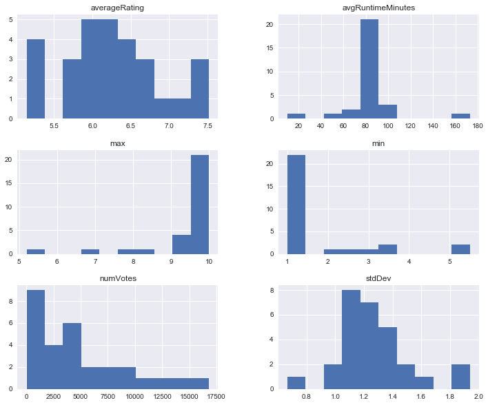

```python
genre_avg.hist()
```

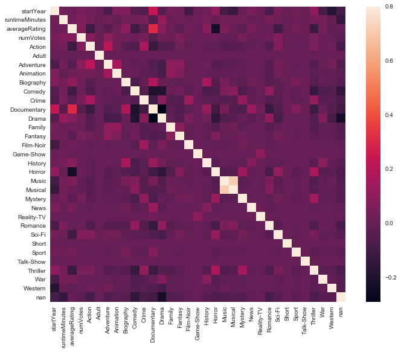

```python
# correlation matrix
corrmatrix = movie_data_expanded.corr()
f, ax = plt.subplots(figsize=(12, 9))
sns.heatmap(corrmatrix, vmax=0.8, square=True)
```

```python
#columns = [genres_series, 'averageRating', 'numVotes', 'runtimeMinutes']

#genre_avg = pd.DataFrame

#movie_data_expanded[movie_data_expanded.Action == 'True'].head()
```

May also want to look into how well movies performed by region. Would need to use the title.akas.tsv file to analyze this.

### Save Dataframes for Other Notebooks

Save cleaned data to a csv for later analysis in another notebook.

```python
#genre_avg.to_csv("../Data/genre_avg_data.csv", sep='\t', index=False)
movie_data_expanded.to_csv("../Data/movie_data_expanded.csv", sep='\t', index=False)
```

```python
# save a skinny table for the "Crew Analysis" workbook
columns = ['tconst', 'startYear']

movie_data_years = pd.DataFrame(movie_data_expanded[columns]).copy(deep=True)

movie_data_years.to_csv("../Data/movie_data_years.csv", sep='\t', index=False)
```

### Determine the Target Average Rating

Pandas [`.plot()`](https://pandas.pydata.org/pandas-docs/stable/generated/pandas.DataFrame.plot.html) method and [Visualization](https://pandas.pydata.org/pandas-docs/stable/visualization.html) guide for reference.

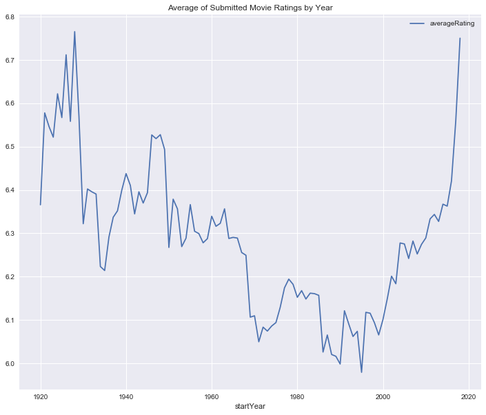

```python
# plot the average movie rating by year
movie_pivot = current_movie_data.pivot_table(index="startYear", values=["averageRating"])

movie_pivot.plot(kind='line', title='Average of Submitted Movie Ratings by Year')
```

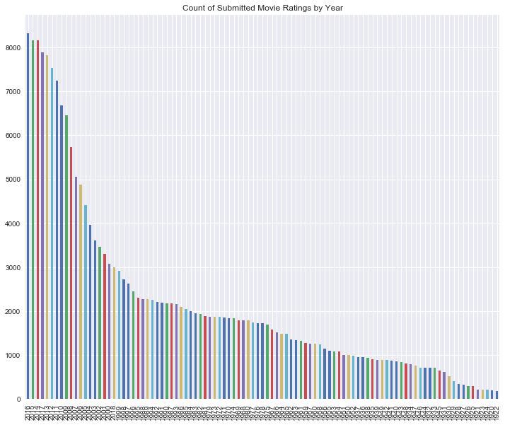

```python
# plot the number of movie reviews per year
movie_pivot = current_movie_data['startYear'].value_counts()

movie_pivot.plot(kind='bar', title='Count of Submitted Movie Ratings by Year')
```

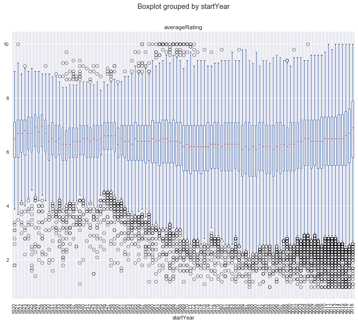

```python
current_movie_data.boxplot(column='averageRating', by='startYear')
plt.xticks(rotation=90)
```

Plot the Density or kernel density estimation (KDE) of the average ratings by year to estimate the probability density function (PDF) using the [`.plot.kde()`](https://pandas.pydata.org/pandas-docs/stable/generated/pandas.DataFrame.plot.kde.html) DataFrame method.

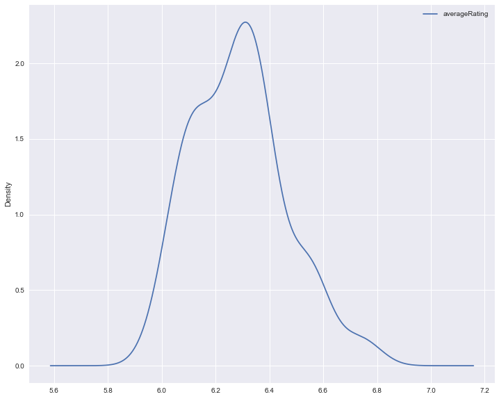

```python
# create a Series of the average movie rating by year
movie_pivot = current_movie_data.pivot_table(index="startYear", values=["averageRating"])

# plot the Density or (KDE)
movie_pivot.plot.kde()
```

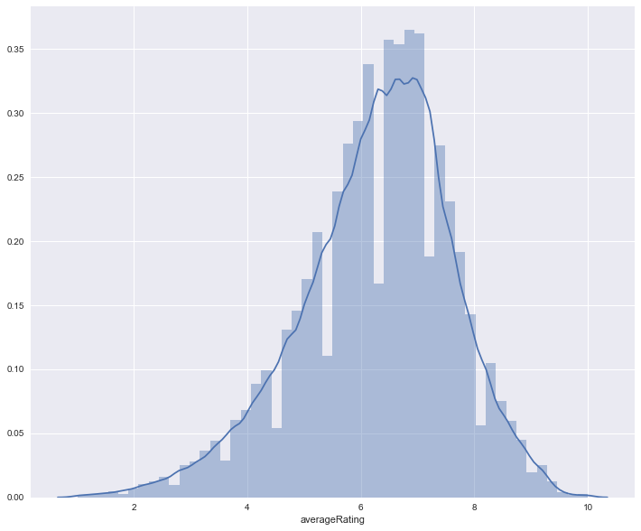

```python
sns.distplot(current_movie_data['averageRating'])
```

References from the Kaggle Notebook [Comprehensive Data Exploration with Python](https://www.kaggle.com/pmarcelino/comprehensive-data-exploration-with-python)

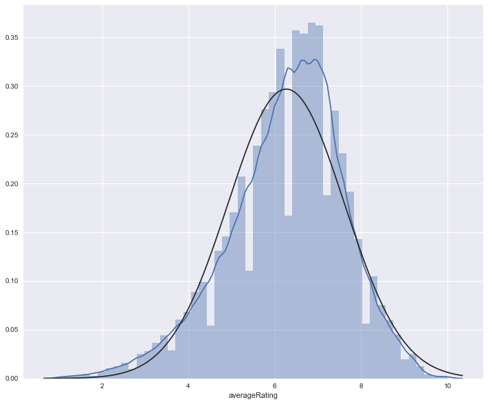

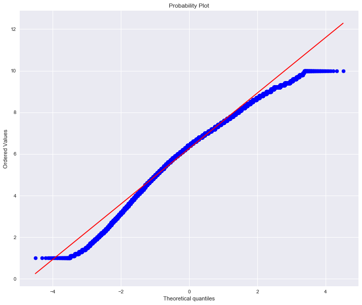

```python
# test the normality of averageRating (should look like a normal distribution)
# histogram & normal probability plot
sns.distplot(current_movie_data['averageRating'], fit=norm)
fig = plt.figure()
res = stats.probplot(current_movie_data['averageRating'], plot=plt)
```

The averageRating is a normal linear distribution.

```python
q1 = movie_pivot.averageRating.quantile(0.25)  # first quartile
q3 = movie_pivot.averageRating.quantile(0.75)  # third quartile
IQR = q3 - q1  # IQR
lower_threshold = q1 - 1.5 * IQR  # lower threshold
upper_threshold = q3 + 1.5 * IQR  # upper threshold
display(lower_threshold, upper_threshold)
```

```
5.814657345413752
```

```
6.710013463510324
```

Next will look at the stats for the `averageRating` and plot a histogram of the quantiles to determine if we can define/prove what a high rating movie is. The below uses the "[Happy Healthy Hungry -- San Francisco](http://nbviewer.jupyter.org/github/Jay-Oh-eN/happy-healthy-hungry/blob/master/h3.ipynb)" notebook analysis as reference.

```python
ratings = current_movie_data['averageRating']
ratings_mean = ratings.mean()
ratings_median = ratings.median()

# compute descriptive summary stats of the movie ratings
ratings_summary = ratings.describe()

ratings_mode = sp.stats.mode(ratings)
skew = ratings.skew()
kurt = ratings.kurt()

# compute quantiles
ninety = ratings.quantile(0.9)
eighty = ratings.quantile(0.8)
seventy = ratings.quantile(0.7)
sixty = ratings.quantile(0.6)

print('Skew: ', str(skew))
print('Kurtosis: ', str(kurt))
print('90%: ', str(ninety))
print('80%: ', str(eighty))
print('70%: ', str(seventy))
print('60%: ', str(sixty))
print(ratings_summary)
```

```
Skew:  -0.5149214491323041
Kurtosis:  0.4010134416583222
90%:  7.799999999999999
80%:  7.299999999999999
70%:  7.0
60%:  6.700000000000001
count    216015.000000
mean          6.264803
std           1.343718
min           1.000000
25%           5.500000
50%           6.400000
75%           7.200000
max          10.000000
Name: averageRating, dtype: float64
```

```
count    216015.000000
mean          6.264803
std           1.343718
min           1.000000
25%           5.500000
50%           6.400000
75%           7.200000
max          10.000000
Name: averageRating, dtype: float64
```

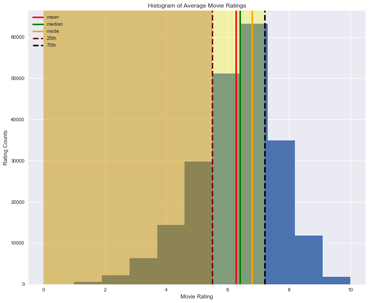

```python
# histogram
h = current_movie_data['averageRating'].hist(bins=10)

# summary statistics vertical lines
h.axvline(x=ratings_mean, color='red', ls='solid', lw='3', label='mean')
h.axvline(x=ratings_median, color='green', ls='solid', lw='3', label='median')
h.axvline(x=ratings_mode[0][0], color='orange', ls='solid', lw='3', label='mode')

# 25th quantile
h.axvline(x=ratings_summary['25%'], color='maroon', ls='dashed', lw='3', label='25th')
h.axvspan(0, ratings_summary['25%'], facecolor='maroon', alpha=0.3)

# 75th quantile
h.axvline(x=ratings_summary['75%'], color='black', ls='dashed', lw='3', label='75th')
h.axvspan(0, ratings_summary['75%'], facecolor='yellow', alpha=0.3)

# add legend to graph
h.legend(loc=2)

# add a title to the figure
h.set_title('Histogram of Average Movie Ratings')

# set axis labels
h.set_xlabel('Movie Rating')
h.set_ylabel('Rating Counts')

print(ratings_summary)
```

**Defining High Rated movie with a rating of 8.** Why? The 90% quantile is a rating of 8.

First, we will create a new column in our dataframe that identifies all high rated movies, as defined above.

```python
# create new column for new variable
movie_data_expanded['highRating'] = pd.Series(len(movie_data_expanded['averageRating']),
                                              index=movie_data_expanded.index)

# default new column to 0
movie_data_expanded['highRating'] = 0

# 1 if avg rating 8 or more; 0 if avg rating < 8
movie_data_expanded.loc[movie_data_expanded['averageRating'] >= 8, 'highRating'] = 1
```

```python
movie_data_expanded.highRating.value_counts()
```

```
0    197268
1     18747
Name: highRating, dtype: int64
```

## Model the Data

```python
from sklearn.tree import DecisionTreeRegressor
from sklearn.ensemble import RandomForestRegressor
#from sklearn.metrics import mean_absolute_error
#from sklearn.model_selection import cross_val_score
from sklearn.model_selection import train_test_split
from sklearn.preprocessing import StandardScaler
from sklearn import metrics
```

Nice to have, plot a comparison of different algorithms and their prediction accuracy. Somthing similar to [How To Compare Machine Learning Algorithms in Python with scikit-learn](https://machinelearningmastery.com/compare-machine-learning-algorithms-python-scikit-learn/).

Other Resources that may be helpful for Modeling:

- [A Complete Machine Learning Project Walk-Through in Python: Part One](https://towardsdatascience.com/a-complete-machine-learning-walk-through-in-python-part-one-c62152f39420)
- [A Complete Machine Learning Walk-Through in Python: Part Two](https://towardsdatascience.com/a-complete-machine-learning-project-walk-through-in-python-part-two-300f1f8147e2)
- [A Complete Machine Learning Walk-Through in Python: Part Three](https://towardsdatascience.com/a-complete-machine-learning-walk-through-in-python-part-three-388834e8804b)
- [Handling Categorical Data in Python](https://www.datacamp.com/community/tutorials/categorical-data)
- [Using Categorical Data with One-Hot Encoding](https://www.kaggle.com/dansbecker/using-categorical-data-with-one-hot-encoding)
- 100-Days-Of-ML-Code

### Create Train & Test Datasets

The goal is to predict high rated movies to know what movie should be produced.

Set the prediction target, `averageRating`, as `y`, and set the predictors as `X`.

#### Movie Genres Dataset

```python
# drop unused features
columns = ['primaryTitle', 'originalTitle', 'runtimeMinutes', 'numVotes', 'genres', 'highRating']
movie_data_simplified = movie_data_expanded.drop(columns, axis=1)

# set tconst as the index
movie_data_simplified = movie_data_simplified.set_index(['tconst'])

movie_data_simplified.head()
```

| tconst | startYear | averageRating | Action | Adult | Adventure | Animation | Biography | Comedy | Crime | Documentary | ... | Reality-TV | Romance | Sci-Fi | Short | Sport | Talk-Show | Thriller | War | Western | nan |
| --- | --- | --- | --- | --- | --- | --- | --- | --- | --- | --- | --- | --- | --- | --- | --- | --- | --- | --- | --- | --- | --- |
| tt0003854 | 1936 | 5.6 | 0 | 0 | 1 | 0 | 0 | 0 | 0 | 0 | ... | 0 | 0 | 0 | 0 | 0 | 0 | 0 | 0 | 1 | 0 |
| tt0005076 | 1925 | 6.7 | 0 | 0 | 0 | 0 | 0 | 1 | 0 | 0 | ... | 0 | 0 | 0 | 0 | 0 | 0 | 0 | 0 | 0 | 0 |
| tt0008933 | 1921 | 9.0 | 0 | 0 | 0 | 0 | 0 | 0 | 0 | 0 | ... | 0 | 0 | 0 | 0 | 0 | 0 | 0 | 0 | 0 | 0 |
| tt0009771 | 1920 | 5.2 | 0 | 0 | 0 | 0 | 0 | 0 | 0 | 0 | ... | 0 | 0 | 0 | 0 | 0 | 0 | 0 | 0 | 0 | 0 |
| tt0010058 | 1920 | 6.9 | 0 | 0 | 0 | 0 | 0 | 1 | 0 | 0 | ... | 0 | 0 | 0 | 0 | 0 | 0 | 0 | 0 | 0 | 0 |

5 rows × 31 columns

```python
#train_movie_data = movie_data_simplified.loc[movie_data_expanded['startYear'] < 2018]
# drop the target column from the training data
#train_movie_data = train_movie_data.drop(['averageRating'], axis=1)

#test_movie_data = movie_data_simplified.loc[movie_data_expanded['startYear'] >= 2018]

# save the datasets to csv files
#train_movie_data.to_csv("../Data/train_movie_data.csv", sep='\t', index=False)
#test_movie_data.to_csv("../Data/test_movie_data.csv", sep='\t', index=False)
```

```python
# set the prediction target column
y_genre = movie_data_simplified.averageRating

# set the predictor columns (not including the 'nan' genre column)
movie_predictors = ['Action', 'Adult', 'Adventure', 'Animation',
                    'Biography', 'Comedy', 'Crime', 'Documentary', 'Drama', 'Family', 'Fantasy', 'Game-Show',
                    'History', 'Horror', 'Music', 'Musical', 'Mystery', 'News', 'Reality-TV', 'Romance', 'Sci-Fi',
                    'Short', 'Sport', 'Talk-Show', 'Thriller', 'War', 'Western']

X_genre = movie_data_simplified[movie_predictors]

# Split the data into training and validation data
train_X_g, val_X_g, train_y_g, val_y_g = train_test_split(X_genre, y_genre, random_state=0, test_size=0.20)
```

#### titlePrincipals Dataset

```python
# load the tab-delimited csv file
principal_rollup = pd.read_csv('../Modeling/DataToModel8-10-2018.csv')

principal_rollup.head()
```

|  | Unnamed: 0 | tconst | titleType | primaryTitle | originalTitle | isAdult | startYear | endYear | runtimeMinutes | genres | averageRating | numVotes | myVoteVolume | myActor_averageRating | myProducer_averageRating | myWriter_averageRating | myDirector_averageRating | myComposer_averageRating | myCinematographer_averageRating | myEditor_averageRating |
| --- | --- | --- | --- | --- | --- | --- | --- | --- | --- | --- | --- | --- | --- | --- | --- | --- | --- | --- | --- | --- |
| 0 | 0 | tt0005076 | movie | Charley's Aunt | Charley's Aunt | 0 | 1925 | \N | 80 | Comedy | 6.7 | 37 | low | 6.203211 | 6.413208 | 6.435604 | 6.566667 | 6.009677 | NaN | NaN |
| 1 | 1 | tt0008933 | movie | Die Brüder Karamasoff | Die Brüder Karamasoff | 0 | 1921 | \N | 70 | Drama | 9.0 | 8 | low | 6.998206 | 7.450000 | 6.916239 | 6.986830 | NaN | 6.740000 | NaN |
| 2 | 2 | tt0009771 | movie | A víg özvegy | A víg özvegy | 0 | 1920 | \N | 70 | Musical | 5.2 | 12 | low | 5.475000 | 5.200000 | 7.052070 | 6.070588 | 6.150000 | 6.597297 | NaN |
| 3 | 3 | tt0010058 | movie | The Deadlier Sex | The Deadlier Sex | 0 | 1920 | \N | 60 | Comedy,Drama | 6.9 | 8 | low | 6.377161 | 6.900000 | 6.345175 | 6.983333 | NaN | 6.050000 | NaN |
| 4 | 4 | tt0010764 | movie | Theodora | Teodora | 0 | 1921 | \N | \N | Drama | 9.2 | 9 | low | 8.838889 | 5.505556 | 7.208571 | 9.200000 | NaN | 8.250000 | NaN |

```python
columns = ['Unnamed: 0', 'runtimeMinutes', 'titleType', 'numVotes', 'primaryTitle', 'originalTitle', 'genres',
           'isAdult', 'endYear', 'myVoteVolume', 'myComposer_averageRating', 'myCinematographer_averageRating',
           'myEditor_averageRating']

# drop unused features
principal_rollup = principal_rollup.drop(columns, axis=1)

# replace nulls with NaN
principal_rollup = principal_rollup.replace({'\\N': np.nan})

# set tconst as the index
principal_rollup = principal_rollup.set_index(['tconst'])

principal_rollup.head()
```

| tconst | startYear | averageRating | myActor_averageRating | myProducer_averageRating | myWriter_averageRating | myDirector_averageRating |
| --- | --- | --- | --- | --- | --- | --- |
| tt0005076 | 1925 | 6.7 | 6.203211 | 6.413208 | 6.435604 | 6.566667 |
| tt0008933 | 1921 | 9.0 | 6.998206 | 7.450000 | 6.916239 | 6.986830 |
| tt0009771 | 1920 | 5.2 | 5.475000 | 5.200000 | 7.052070 | 6.070588 |
| tt0010058 | 1920 | 6.9 | 6.377161 | 6.900000 | 6.345175 | 6.983333 |
| tt0010764 | 1921 | 9.2 | 8.838889 | 5.505556 | 7.208571 | 9.200000 |

```python
# set the prediction target column
y_principal = principal_rollup.averageRating

# set the predictor columns
rating_predictors = ['myActor_averageRating', 'myProducer_averageRating', 'myWriter_averageRating',
                    'myDirector_averageRating']

X_principal = principal_rollup[rating_predictors]

# create the training and validation data
train_X_p, val_X_p, train_y_p, val_y_p = train_test_split(X_principal, y_principal, random_state=0, test_size=0.33)
```

```python
# Feature Scaling
#sc = StandardScaler()

#train_X_p = sc.fit_transform(train_X_p)
#val_X_p = sc.transform(val_X_p)
```

### Movie Genre Dataset Modeling

#### Movie Genre Decision Tree Model

The first model will be a decision tree using the sklearn `DecisionTreeRegressor()` method.

```python
# define the model
genre_tree_model = DecisionTreeRegressor()

# fit the model
genre_tree_model.fit(train_X_g, train_y_g)

# get predicted ratings on validation data
genreRating_predictions = genre_tree_model.predict(val_X_g)

print('Mean Absolute Error: %.3f' % metrics.mean_absolute_error(val_y_g, genreRating_predictions))
print('Mean Squared Error: %.3f' % metrics.mean_squared_error(val_y_g, genreRating_predictions))
print('Root Mean Squared Error: %.3f' % np.sqrt(metrics.mean_squared_error(val_y_g, genreRating_predictions)))
print('Variance Score: %.3f' % genre_tree_model.score(X_genre, y_genre, sample_weight=None))
```

```
Mean Absolute Error: 0.937
Mean Squared Error: 1.465
Root Mean Squared Error: 1.210
Variance Score: 0.184
```

```python
dTree_g = pd.DataFrame({'Actual':val_y_g, 'Predicted':genreRating_predictions})
dTree_g.head()
```

| tconst | Actual | Predicted |
| --- | --- | --- |
| tt0111525 | 4.8 | 6.304430 |
| tt2281503 | 6.1 | 7.556129 |
| tt0967932 | 6.1 | 6.455424 |
| tt0049014 | 5.1 | 6.639941 |
| tt2630866 | 3.8 | 5.842661 |

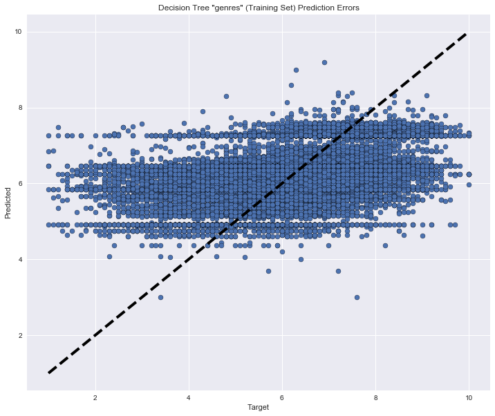

```python
# Visualize the Training Set Results
# Source: http://scikit-learn.org/stable/auto_examples/plot_cv_predict.html
fig, ax = plt.subplots()
ax.scatter(dTree_g.Actual, dTree_g.Predicted, edgecolors=(0, 0, 0))
ax.plot([dTree_g.Actual.min(), dTree_g.Actual.max()],
        [dTree_g.Actual.min(), dTree_g.Actual.max()],
        'k--', lw=4)
ax.set_xlabel('Target')
ax.set_ylabel('Predicted')
ax.set_title('Decision Tree "genres" (Training Set) Prediction Errors')
plt.show()
```

#### Movie Genre Random Forest Model

The next model will be a random forest model using the sklearn `RandomForestRegressor()` method.

```python
# define the model
genre_forest_model = RandomForestRegressor(random_state=1)

# fit the model
genre_forest_model.fit(train_X_g, train_y_g)

# get predicted ratings on validation data
genreRating_predictions = genre_forest_model.predict(val_X_g)

print('Mean Absolute Error: %.3f' % metrics.mean_absolute_error(val_y_g, genreRating_predictions))
print('Mean Squared Error: %.3f' % metrics.mean_squared_error(val_y_g, genreRating_predictions))
print('Root Mean Squared Error: %.3f' % np.sqrt(metrics.mean_squared_error(val_y_g, genreRating_predictions)))
print('Variance Score: %.3f' % genre_forest_model.score(X_genre, y_genre, sample_weight=None))
```

```
Mean Absolute Error: 0.937
Mean Squared Error: 1.465
Root Mean Squared Error: 1.210
Variance Score: 0.183
```

```python
rForest_g = pd.DataFrame({'Actual':val_y_g, 'Predicted':genreRating_predictions})
rForest_g.head()
```

| tconst | Actual | Predicted |
| --- | --- | --- |
| tt0111525 | 4.8 | 6.311263 |
| tt2281503 | 6.1 | 7.540650 |
| tt0967932 | 6.1 | 6.459645 |
| tt0049014 | 5.1 | 6.667160 |
| tt2630866 | 3.8 | 5.849259 |

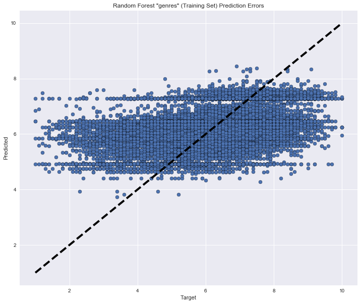

```python
# Visualize the Training Set Results
# Source: http://scikit-learn.org/stable/auto_examples/plot_cv_predict.html
fig, ax = plt.subplots()
ax.scatter(rForest_g.Actual, rForest_g.Predicted, edgecolors=(0, 0, 0))
ax.plot([rForest_g.Actual.min(), rForest_g.Actual.max()],
        [rForest_g.Actual.min(), rForest_g.Actual.max()],
        'k--', lw=4)
ax.set_xlabel('Target')
ax.set_ylabel('Predicted')
ax.set_title('Random Forest "genres" (Training Set) Prediction Errors')
plt.show()
```

### titlePrincipal Dataset Modeling

#### titlePrincipal Decision Tree

```python
# define the model
principalRating_model = DecisionTreeRegressor()

# fit the model
principalRating_model.fit(train_X_p, train_y_p)

# get predicted ratings on validation data
principalRating_predictions = principalRating_model.predict(val_X_p)

print('Mean Absolute Error: %.3f' % metrics.mean_absolute_error(val_y_p, principalRating_predictions))
print('Mean Squared Error: %.3f' % metrics.mean_squared_error(val_y_p, principalRating_predictions))
print('Root Mean Squared Error: %.3f' % np.sqrt(metrics.mean_squared_error(val_y_p, principalRating_predictions)))
print('Variance Score: %.3f' % principalRating_model.score(X_principal, y_principal, sample_weight=None))
```

```
Mean Absolute Error: 0.661
Mean Squared Error: 0.856
Root Mean Squared Error: 0.925
Variance Score: 0.808
```

```python
dTree_p = pd.DataFrame({'Actual':val_y_p, 'Predicted':principalRating_predictions})
dTree_p.head()
```

| tconst | Actual | Predicted |
| --- | --- | --- |
| tt0970866 | 5.5 | 7.0 |
| tt0459863 | 4.0 | 4.7 |
| tt0099511 | 6.4 | 6.8 |
| tt1715741 | 5.2 | 5.2 |
| tt4636068 | 6.4 | 7.3 |

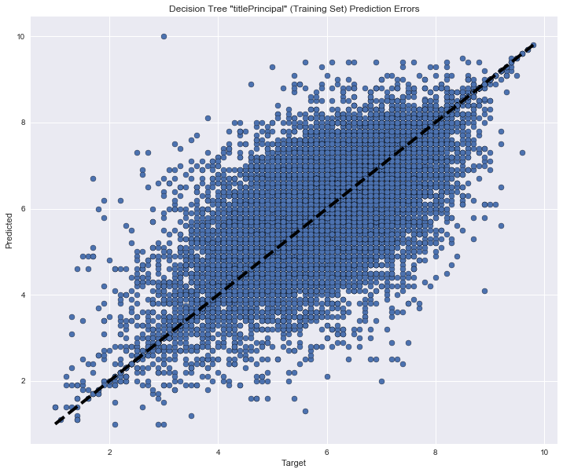

```python
# Visualize the Training Set Results
# Source: http://scikit-learn.org/stable/auto_examples/plot_cv_predict.html
fig, ax = plt.subplots()
ax.scatter(dTree_p.Actual, dTree_p.Predicted, edgecolors=(0, 0, 0))
ax.plot([dTree_p.Actual.min(), dTree_p.Actual.max()],
        [dTree_p.Actual.min(), dTree_p.Actual.max()],
        'k--', lw=4)
ax.set_xlabel('Target')
ax.set_ylabel('Predicted')
ax.set_title('Decision Tree "titlePrincipal" (Training Set) Prediction Errors')
plt.show()
```

#### titlePrincipal Random Forest Model

```python
# define the model
principal_forest_model = RandomForestRegressor(random_state=1)

# fit the model
principal_forest_model.fit(train_X_p, train_y_p)

# get predicted ratings on validation data
principalRating_predictions = principal_forest_model.predict(val_X_p)

print('Mean Absolute Error: %.3f' % metrics.mean_absolute_error(val_y_p, principalRating_predictions))
print('Mean Squared Error: %.3f' % metrics.mean_squared_error(val_y_p, principalRating_predictions))
print('Root Mean Squared Error: %.3f' % np.sqrt(metrics.mean_squared_error(val_y_p, principalRating_predictions)))
print('Variance Score: %.3f' % principal_forest_model.score(X_principal, y_principal, sample_weight=None))
```

```
Mean Absolute Error: 0.497
Mean Squared Error: 0.475
Root Mean Squared Error: 0.689
Variance Score: 0.855
```

```python
rForest_p = pd.DataFrame({'Actual':val_y_p, 'Predicted':principalRating_predictions})
rForest_p.head()
```

| tconst | Actual | Predicted |
| --- | --- | --- |
| tt0970866 | 5.5 | 6.30 |
| tt0459863 | 4.0 | 3.94 |
| tt0099511 | 6.4 | 6.79 |
| tt1715741 | 5.2 | 5.20 |
| tt4636068 | 6.4 | 6.96 |

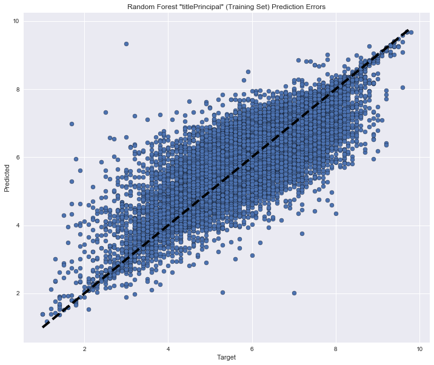

```python
# Visualize the Training Set Results
# Source: http://scikit-learn.org/stable/auto_examples/plot_cv_predict.html
fig, ax = plt.subplots()
ax.scatter(rForest_p.Actual, rForest_p.Predicted, edgecolors=(0, 0, 0))
ax.plot([rForest_p.Actual.min(), rForest_p.Actual.max()],
        [rForest_p.Actual.min(), rForest_p.Actual.max()],
        'k--', lw=4)
ax.set_xlabel('Target')
ax.set_ylabel('Predicted')
ax.set_title('Random Forest "titlePrincipal" (Training Set) Prediction Errors')
plt.show()
```

#### titlePrincipal Random Forest Model with 2018 Validation Data

```python
# create the train data with movies prior to 2018
#train_movie_data = principal_rollup.loc[principal_rollup['startYear'] < 2018]
# drop the target column from the training data
#train_movie_data = train_movie_data.drop(['averageRating'], axis=1)

# create the test data with 2018 only
test_movie_data = principal_rollup.loc[principal_rollup['startYear'] >= 2018]

# create X and Y dataframes
test_movie_data_X = test_movie_data.drop(['startYear', 'averageRating'], axis=1)
test_movie_data_y = test_movie_data.drop(['startYear', 'myActor_averageRating', 'myProducer_averageRating',
                                          'myWriter_averageRating', 'myDirector_averageRating'], axis=1)
```

```python
# get predicted ratings on validation data
principalRating_predictions_2018 = principal_forest_model.predict(test_movie_data_X)
```

```python
# https://datascience.stackexchange.com/questions/18904/how-do-i-convert-a-pandas-dataframe-to-a-1d-array
rForest_p18 = pd.DataFrame({'Actual':test_movie_data_y.values.ravel(), 'Predicted':principalRating_predictions_2018})
rForest_p18.head(10)
```

|  | Actual | Predicted |
| --- | --- | --- |
| 0 | 4.9 | 5.77 |
| 1 | 6.9 | 6.81 |
| 2 | 5.4 | 5.38 |
| 3 | 6.4 | 6.46 |
| 4 | 7.0 | 6.84 |
| 5 | 5.2 | 5.35 |
| 6 | 6.5 | 6.92 |
| 7 | 6.4 | 6.57 |
| 8 | 6.6 | 6.60 |
| 9 | 6.6 | 6.85 |

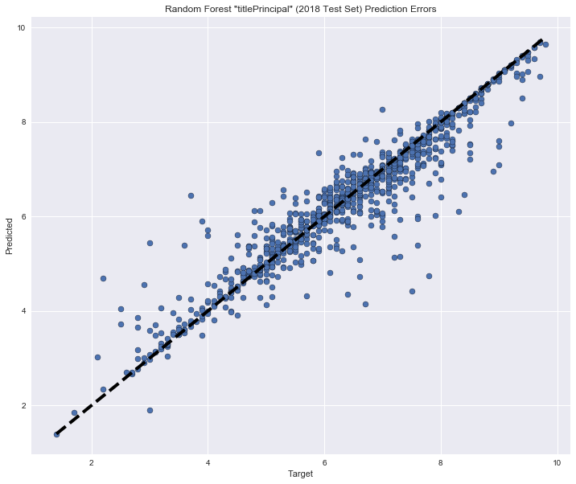

```python
# Visualize the Training Set Results
# Source: http://scikit-learn.org/stable/auto_examples/plot_cv_predict.html
fig, ax = plt.subplots()
ax.scatter(rForest_p18.Actual, rForest_p18.Predicted, edgecolors=(0, 0, 0))
ax.plot([rForest_p18.Actual.min(), rForest_p18.Actual.max()],
        [rForest_p18.Actual.min(), rForest_p18.Actual.max()],
        'k--', lw=4)
ax.set_xlabel('Target')
ax.set_ylabel('Predicted')
ax.set_title('Random Forest "titlePrincipal" (2018 Test Set) Prediction Errors')
plt.show()
```

## Visualize the Results

Potential resource for ploting results: [Python Plotting With Matplotlib (Guide)](https://realpython.com/python-matplotlib-guide/)